# Activity patterns

Marie Gilbertson

2024-02-05

# Introduction

Below, I demonstrate using white-tailed deer movement data to generate 24-hour activity patterns figures. For data ownership reasons, the data is not itself publicly available. However, I will demonstrate the data structure to facilitate replication if readers would like to generate similar figures themselves. In addition, the data can be requested from the Wisconsin Department of Natural Resources.

We’ll start by loading the packages we’ll need. I also always set my seed as standard practice (this makes randomization reproducible).

```r
##### Clear Environment #####
remove(list=ls())


#### set seed ####
set.seed(3571)


#### load libraries ####
library(amt)
library(pbapply)
library(tidyr)
library(ggplot2)
library(MetBrewer)
library(plyr)
library(dplyr)
library(mgcv)
```

## Load and preview data

As stated in the introduction, the data itself is not publicly available, but I can give you a preview for replication purposes.

```r
# load movement data
mdat <- get(load("../Project_data/SSF_data with covar_4hrstep_24hrslice_reclassed_042123.Rdata"))

# load metadata
meta <- get(load("../Project_data/metadata_assembled_051022.Rdata"))

# review movement data
class(mdat)
```

```
## [1] "nested_track" "tbl_df"       "tbl"          "data.frame"
```

```r
# preview
print(head(mdat), width = Inf)
```

```
## # A tibble: 6 × 14
##   id    season  year data                 age.at.col1 sex    indicator
##   <chr> <chr>  <dbl> <list>               <chr>       <chr>  <chr>
## 1 5066  nb      2016 <trck_xyt [627 × 3]> 20mo        Female 5066_nb_2016
## 2 5090  nb      2016 <trck_xyt [621 × 3]> 8mo         Female 5090_nb_2016
## 3 5094  nb      2016 <trck_xyt [618 × 3]> 8mo         Female 5094_nb_2016
## 4 5006  nb      2016 <trck_xyt [632 × 3]> >2yrs       Female 5006_nb_2016
## 5 5088  nb      2016 <trck_xyt [619 × 3]> >2yrs       Female 5088_nb_2016
## 6 5892  nb      2016 <trck_xyt [626 × 3]> 8mo         Male   5892_nb_2016
##   resamp               norep                n.days max.dur day.cov
##   <list>               <list>                <int>   <dbl>   <dbl>
## 1 <trck_xyt [612 × 4]> <trck_xyt [612 × 4]>    109     136   0.801
## 2 <trck_xyt [595 × 4]> <trck_xyt [595 × 4]>    108     136   0.794
## 3 <trck_xyt [589 × 4]> <trck_xyt [589 × 4]>    109     136   0.801
## 4 <trck_xyt [629 × 4]> <trck_xyt [629 × 4]>    109     136   0.801
## 5 <trck_xyt [619 × 4]> <trck_xyt [619 × 4]>    105     136   0.772
## 6 <trck_xyt [621 × 4]> <trck_xyt [621 × 4]>    105     136   0.772
##   stp                   stp.var
##   <list>                <list>
## 1 <stps_xyt [587 × 11]> <rndm_stp [6,457 × 33]>
## 2 <stps_xyt [574 × 11]> <rndm_stp [6,314 × 33]>
## 3 <stps_xyt [550 × 11]> <rndm_stp [6,050 × 33]>
## 4 <stps_xyt [612 × 11]> <rndm_stp [6,732 × 33]>
## 5 <stps_xyt [611 × 11]> <rndm_stp [6,721 × 33]>
## 6 <stps_xyt [613 × 11]> <rndm_stp [6,743 × 33]>
```

From the preview and data type, we can see that we are working with a “nested_track” object; each row of our mdat object represents a single individual (“id”) in a single season (“season”) in a single year (“year”). Each entry in the “stp” column then contains a data frame with the movement data for that id/season/year combination. We’ll refer to these as **trajectories.** These nested track objects are made with the amt package and can be really useful for managing large movement data sets.

Let’s take a look at one of these movement data sets:

```r
print(head(mdat$stp[[1]]), width = Inf)
```

```
## # A tibble: 6 × 11
##   burst_     x1_     x2_     y1_     y2_     sl_ direction_p    ta_
## *  <dbl>   <dbl>   <dbl>   <dbl>   <dbl>   <dbl>       <dbl>  <dbl>
## 1      1 515983. 515935. 280602. 280586.  50.5        -2.82  NA
## 2      1 515935. 515483. 280586. 281274. 822.          2.15  -1.31
## 3      1 515483. 515814. 281274. 281064. 392.         -0.565 -2.72
## 4      1 515814. 515824. 281064. 281076.  15.7         0.881  1.45
## 5      1 515824. 515823. 281076. 281076.   0.998      -3.08   2.32
## 6      1 515823. 515820. 281076. 281080.   4.81        2.24  -0.962
##   t1_                 t2_                 dt_
## * <dttm>              <dttm>              <drtn>
## 1 2017-01-12 06:00:29 2017-01-12 10:00:29 4.000000 hours
## 2 2017-01-12 10:00:29 2017-01-12 14:00:22 3.998056 hours
## 3 2017-01-12 14:00:22 2017-01-12 18:00:29 4.001944 hours
## 4 2017-01-12 18:00:29 2017-01-12 22:00:29 4.000000 hours
## 5 2017-01-12 22:00:29 2017-01-13 02:00:49 4.005556 hours
## 6 2017-01-13 02:00:49 2017-01-13 06:00:23 3.992778 hours
```

From this preview, we can see what the amt package’s track data looks like. Each row represents a “step” with a starting point (x1_ and y1_) and an ending point (x2_ and y2_). Each row then also includes characteristics of that step, including the step length (sl_) and elapsed time (dt_).

When evaluating activity patterns, we’ll look at movement rates by different times of day; we can calculate that by dividing the step length (sl_) by the time elapsed (dt_). The amt package therefore makes it very simple to make these calculations. However, we want to make sure that our fix rates are fairly consistent across time and across individuals. This is because the fix rate can have an impact on the movement rates we calculate. For example, if an animal has very tortuous movement (i.e., very windy), if we take many locations along their windy trajectory, we might calculate a fairly high movement rate. However, if we take very low locations along that trajectory, we might instead calculate quite a low movement rate simply because they don’t appear to move very much thanks to their tortuous movement. We therefore want to make sure we have consistent fix rates to avoid introducing bias when calculating movement rates.

This data was previously cleaned using amt functions (track_resample and filter_min_n_burst) to ensure we have consistent, ~4 hour fix rates but we can verify that.

```r
frs <- unlist(lapply(mdat$stp, function(x) mean(as.numeric(x$dt_)))) # take the average fix rate for a trajectory
summary(frs) # and now look at a summary of the mean fix rates across all trajectories
```

```
##    Min. 1st Qu.  Median    Mean 3rd Qu.    Max.
##   3.996   4.000   4.000   4.000   4.000   4.023
```

We see that we have nice, consistent fix rates! Now we can proceed to the activity pattern analysis.

## Exploring daily cycles

Our data is in step format, which makes it easy to calculate activity rates, but if we want to look at how activity rates change with a 24 period, we need to assign 24-hour time to each step. Because we don’t want hourly activity rates to seem to shift in response to Daylight Saving Time (DST), we’ll put all our times in a Central time zone that does not use DST.

In addition, interpreting activity across hundreds of individuals years worth of data requires some summarizing. Because we were interested in exploring how activity patterns change through the year, we’ll summarize activity patterns by averaging hourly movement rates within a given week in the year.

```r
dc <- mdat %>%
  mutate(act = lapply(stp, function(x){
    temp <- x # each x (or "temp" object) represents a single trajectory of movement data (i.e., one individual in one season in one year)

    # assign Julian day within the focal year (i.e., day number of the year)
    temp$origin <- as.Date(paste0(format(temp$t1_, "%Y"), "-01-01"), tz = "America/Chicago") # set Jan 1 of the step's year as the "origin" for calculating Julian date
    temp$day <- as.Date(temp$t1_, tz = "America/Chicago") # just the date for the step (not the date-time)
    temp$jday <- NA
    for(i in 1:nrow(temp)){ # cycle through each row in the trajectory and calculate the Julian date
      temp$jday[i] <- julian(temp$day[i], origin = temp$origin[i]) +1 # add 1 so that Jan 1 is "day 1"
    }

    # assign a week by dividing day number by 7 and rounding down (e.g., day 6 = week 0)
    temp$week <- floor(temp$jday/7)

    # now we'll convert times to a time zone that doesn't use DST and extract just the hour
    temp$t1_can <- temp$t1_
    attr(temp$t1_can, "tzone") <- "Canada/Saskatchewan"
    temp$hour.can <- as.numeric(format(temp$t1_can, "%H")) # hour
    temp$met.p.hr <- temp$sl_/as.numeric(temp$dt_) # movement rate in meters per hour
    return(temp)

  }))

print(head(dc), width = Inf) # we now have a new tibble with a new column called "act"
```

```
## # A tibble: 6 × 15
##   id    season  year data                 age.at.col1 sex    indicator
##   <chr> <chr>  <dbl> <list>               <chr>       <chr>  <chr>
## 1 5066  nb      2016 <trck_xyt [627 × 3]> 20mo        Female 5066_nb_2016
## 2 5090  nb      2016 <trck_xyt [621 × 3]> 8mo         Female 5090_nb_2016
## 3 5094  nb      2016 <trck_xyt [618 × 3]> 8mo         Female 5094_nb_2016
## 4 5006  nb      2016 <trck_xyt [632 × 3]> >2yrs       Female 5006_nb_2016
## 5 5088  nb      2016 <trck_xyt [619 × 3]> >2yrs       Female 5088_nb_2016
## 6 5892  nb      2016 <trck_xyt [626 × 3]> 8mo         Male   5892_nb_2016
##   resamp               norep                n.days max.dur day.cov
##   <list>               <list>                <int>   <dbl>   <dbl>
## 1 <trck_xyt [612 × 4]> <trck_xyt [612 × 4]>    109     136   0.801
## 2 <trck_xyt [595 × 4]> <trck_xyt [595 × 4]>    108     136   0.794
## 3 <trck_xyt [589 × 4]> <trck_xyt [589 × 4]>    109     136   0.801
## 4 <trck_xyt [629 × 4]> <trck_xyt [629 × 4]>    109     136   0.801
## 5 <trck_xyt [619 × 4]> <trck_xyt [619 × 4]>    105     136   0.772
## 6 <trck_xyt [621 × 4]> <trck_xyt [621 × 4]>    105     136   0.772
##   stp                   stp.var                 act
##   <list>                <list>                  <list>
## 1 <stps_xyt [587 × 11]> <rndm_stp [6,457 × 33]> <stps_xyt [587 × 18]>
## 2 <stps_xyt [574 × 11]> <rndm_stp [6,314 × 33]> <stps_xyt [574 × 18]>
## 3 <stps_xyt [550 × 11]> <rndm_stp [6,050 × 33]> <stps_xyt [550 × 18]>
## 4 <stps_xyt [612 × 11]> <rndm_stp [6,732 × 33]> <stps_xyt [612 × 18]>
## 5 <stps_xyt [611 × 11]> <rndm_stp [6,721 × 33]> <stps_xyt [611 × 18]>
## 6 <stps_xyt [613 × 11]> <rndm_stp [6,743 × 33]> <stps_xyt [613 × 18]>
```

```r
print(head(dc$act[[1]]), width = Inf)
```

```
## # A tibble: 6 × 18
##   burst_     x1_     x2_     y1_     y2_     sl_ direction_p    ta_
## *  <dbl>   <dbl>   <dbl>   <dbl>   <dbl>   <dbl>       <dbl>  <dbl>
## 1      1 515983. 515935. 280602. 280586.  50.5        -2.82  NA
## 2      1 515935. 515483. 280586. 281274. 822.          2.15  -1.31
## 3      1 515483. 515814. 281274. 281064. 392.         -0.565 -2.72
## 4      1 515814. 515824. 281064. 281076.  15.7         0.881  1.45
## 5      1 515824. 515823. 281076. 281076.   0.998      -3.08   2.32
## 6      1 515823. 515820. 281076. 281080.   4.81        2.24  -0.962
##   t1_                 t2_                 dt_            origin     day
## * <dttm>              <dttm>              <drtn>         <date>     <date>
## 1 2017-01-12 06:00:29 2017-01-12 10:00:29 4.000000 hours 2017-01-01 2017-01-12
## 2 2017-01-12 10:00:29 2017-01-12 14:00:22 3.998056 hours 2017-01-01 2017-01-12
## 3 2017-01-12 14:00:22 2017-01-12 18:00:29 4.001944 hours 2017-01-01 2017-01-12
## 4 2017-01-12 18:00:29 2017-01-12 22:00:29 4.000000 hours 2017-01-01 2017-01-12
## 5 2017-01-12 22:00:29 2017-01-13 02:00:49 4.005556 hours 2017-01-01 2017-01-12
## 6 2017-01-13 02:00:49 2017-01-13 06:00:23 3.992778 hours 2017-01-01 2017-01-13
##    jday  week t1_can              hour.can met.p.hr
## * <dbl> <dbl> <dttm>                 <dbl>    <dbl>
## 1    12     1 2017-01-12 06:00:29        6   12.6
## 2    12     1 2017-01-12 10:00:29       10  206.
## 3    12     1 2017-01-12 14:00:22       14   97.9
## 4    12     1 2017-01-12 18:00:29       18    3.92
## 5    12     1 2017-01-12 22:00:29       22    0.249
## 6    13     1 2017-01-13 02:00:49        2    1.20
```

## Summary activity and exploratory plotting

As described above, to make activity rates interpretable across many individuals and years of data, we’ll summarize activity rates by averaging within a calendar week. We can first “unnest” our tibble.

```r
dc <- dc %>%
  amt::select(id, season, year, act) %>% unnest(cols = act)

print(head(dc), width = Inf) # we now have a dataframe with all trajectory data merged together
```

```
## # A tibble: 6 × 21
##   id    season  year burst_     x1_     x2_     y1_     y2_     sl_ direction_p
## * <chr> <chr>  <dbl>  <dbl>   <dbl>   <dbl>   <dbl>   <dbl>   <dbl>       <dbl>
## 1 5066  nb      2016      1 515983. 515935. 280602. 280586.  50.5        -2.82
## 2 5066  nb      2016      1 515935. 515483. 280586. 281274. 822.          2.15
## 3 5066  nb      2016      1 515483. 515814. 281274. 281064. 392.         -0.565
## 4 5066  nb      2016      1 515814. 515824. 281064. 281076.  15.7         0.881
## 5 5066  nb      2016      1 515824. 515823. 281076. 281076.   0.998      -3.08
## 6 5066  nb      2016      1 515823. 515820. 281076. 281080.   4.81        2.24
##      ta_ t1_                 t2_                 dt_            origin
## *  <dbl> <dttm>              <dttm>              <drtn>         <date>
## 1 NA     2017-01-12 06:00:29 2017-01-12 10:00:29 4.000000 hours 2017-01-01
## 2 -1.31  2017-01-12 10:00:29 2017-01-12 14:00:22 3.998056 hours 2017-01-01
## 3 -2.72  2017-01-12 14:00:22 2017-01-12 18:00:29 4.001944 hours 2017-01-01
## 4  1.45  2017-01-12 18:00:29 2017-01-12 22:00:29 4.000000 hours 2017-01-01
## 5  2.32  2017-01-12 22:00:29 2017-01-13 02:00:49 4.005556 hours 2017-01-01
## 6 -0.962 2017-01-13 02:00:49 2017-01-13 06:00:23 3.992778 hours 2017-01-01
##   day         jday  week t1_can              hour.can met.p.hr
## * <date>     <dbl> <dbl> <dttm>                 <dbl>    <dbl>
## 1 2017-01-12    12     1 2017-01-12 06:00:29        6   12.6
## 2 2017-01-12    12     1 2017-01-12 10:00:29       10  206.
## 3 2017-01-12    12     1 2017-01-12 14:00:22       14   97.9
## 4 2017-01-12    12     1 2017-01-12 18:00:29       18    3.92
## 5 2017-01-12    12     1 2017-01-12 22:00:29       22    0.249
## 6 2017-01-13    13     1 2017-01-13 02:00:49        2    1.20
```

With our merged trajectory data, we can then calculate our averages by week.

```r
all.means <- ddply(dc, .(season, week, hour.can), function(x) mean(x$met.p.hr)) # mean movement rate by season, week, and hour
all.tots <- ddply(dc, .(season, week, hour.can), function(x) length(unique(x$id))) # sample size (unique individuals) by season, week, and hour
colnames(all.tots) <- c("season", "week", "hour.can", "unique.n") # update column names for merging
all.means <- left_join(all.means, all.tots, by = c("season", "week", "hour.can")) # merge the two summaries
head(all.means)
```

```
##   season week hour.can        V1 unique.n
## 1     br   41        0  65.62959       75
## 2     br   41        1  73.42732        3
## 3     br   41        2  61.27122      225
## 4     br   41        3 120.40939      141
## 5     br   41        4  99.36924       74
## 6     br   41        5 169.52495        2
```

Let’s take a look at how many unique individuals contribute to the “mean movement rate” calculations for each season/week/hour.

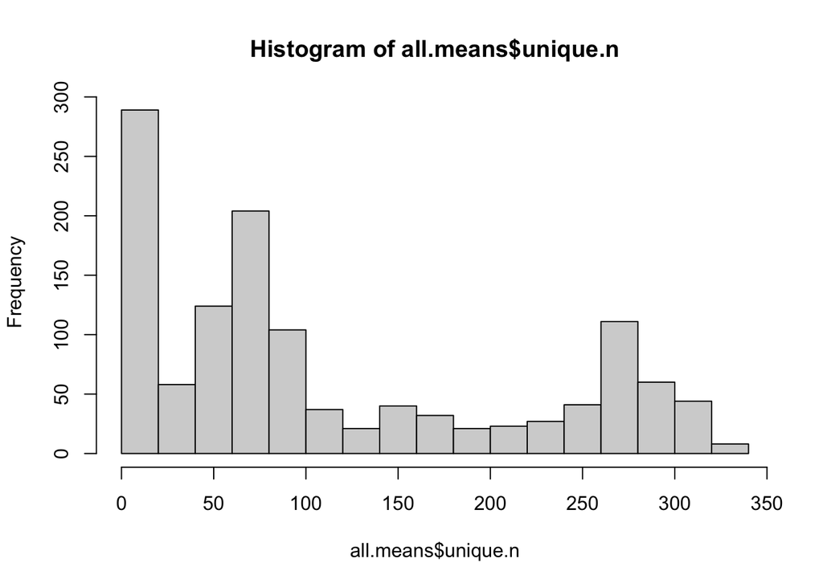

```r
hist(all.means$unique.n)
```

We have a number of observations with very few individuals providing our “average” estimate. That’s not really representative, so we’ll limit future analysis to only those hours with estimates based on at least 10 unique individuals.

```r
all.means <- all.means[all.means$unique.n>=10,]
```

In addition, some weeks lack data for some hours of the day. Activity patterns aren’t very clear if we only have rate estimates for, say, 4 hours in the day. We’ll therefore require a given summarized week to have activity rate estimates for at least 12 hours of the day.

```r
wk.obs <- ddply(all.means, .(season, week), nrow)
head(wk.obs)
```

```
##   season week V1
## 1     br   41 19
## 2     br   42 24
## 3     br   43 24
## 4     br   44 24
## 5     br   45 24
## 6     br   46 24
```

```r
wk.obs <- wk.obs[wk.obs$V1>=12,]
all.means <- all.means[paste0(all.means$season, all.means$week) %in% paste0(wk.obs$season, wk.obs$week),] # extract the weeks that meet our requirements
```

Now that we have our activity rates summarized, we can plot using ggplot.

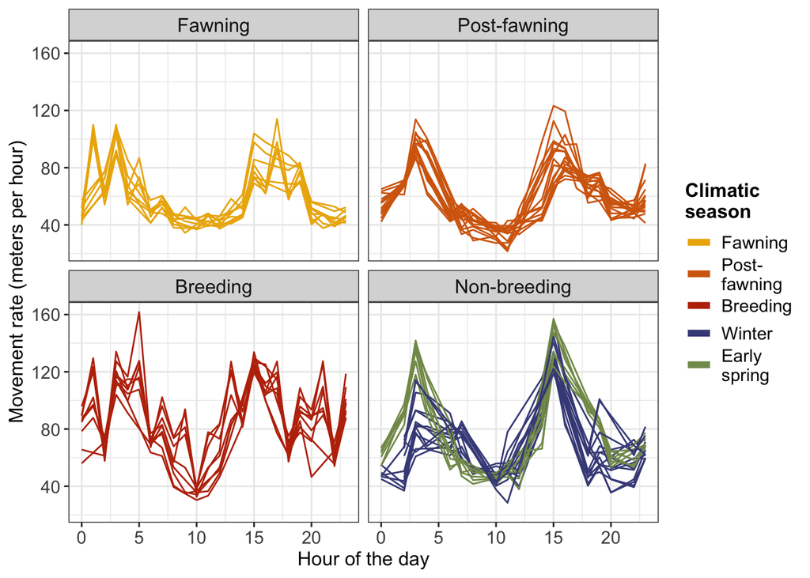

```r
all.means$week.f <- factor(all.means$week) # treat week as a factor
all.means$season <- factor(all.means$season, levels = c("fa", "pf", "br", "nb")) # control levels of seasons so they plot in order

season.labs <- c("Fawning", "Post-fawning", "Breeding", "Non-breeding") # for nice facet labels
names(season.labs) <- c("fa", "pf", "br", "nb")

## split non-breeding season into "winter" and "early spring" and create nice legend labels
all.means$season.col <- as.character(all.means$season)
all.means$season.col <- ifelse(all.means$season.col=="nb" & all.means$week>=11 & all.means$week<=17, "es", all.means$season.col)
all.means$season.col <- factor(all.means$season.col, levels = c("fa", "pf", "br", "nb", "es")) # re-level for plotting in the right order


## now plot!
pal <- met.brewer("VanGogh2", 9)[c(4, 2, 1, 9, 6)] # set our color palette
p <- ggplot(all.means) +
  geom_path(aes(x = hour.can, y = V1, group = week.f, colour = season.col)) +
  facet_wrap(~season, labeller = labeller(season = season.labs)) +
  scale_colour_manual(values = pal, name = "Climatic\nseason",
                      labels = c("Fawning", "Post-\nfawning", "Breeding", "Winter", "Early\nspring")) +
  ylab("Movement rate (meters per hour)") + xlab("Hour of the day") +
  theme_bw() +
  theme(axis.title = element_text(size = 12), axis.text = element_text(size = 11), legend.text = element_text(size = 11),
        legend.title = element_text(size = 12, face = "bold"), strip.text = element_text(size = 12),
        legend.spacing.y = unit(0.5, "cm")) +
  guides(color = guide_legend(byrow = T, override.aes=list(linewidth = 2)))

p
```

Each line represents the movement rates averaged across a given week. We can see how deer activity is crepuscular, with peaks in the morning and late afternoon. We can also see how activity changes through the seasons. In particular, we have split up the non-breeding season into two sub-components - winter and early spring - which seems to correspond to some changes in activity behavior.

From here, we can proceed to statistical modeling.

## Statistical modeling

To model our diel activity cycles, we’ll use generalized additive mixed models (GAMMs). In the accompanying manuscript, we explored various numbers of knots for our GAMMs, but this was fairly time intensive and done with high-throughput computing. Here, we’ll just demonstrate fitting one of these models with six knots, which was the best fit.

Predictors will include season and sex, with season including “winter” and “early-spring,” as identified in our exploratory plotting. As described in the manuscript, we’ll also include an interaction between season and sex, and use cyclic cubic regression splines, with a separate spline model for each season and sex interaction. Lastly, we’ll include random intercepts for individuals.

First, we’ll do some data prep, including breaking our data into training and testing datasets.

```r
## join metadata so we can include sex in our model
dc <- left_join(dc, meta[,c("lowtag", "sex")], by = c("id" = "lowtag"))


## Using FULL dataset, not the weekly averaged one
dc$season_5 <- as.character(dc$season)
dc$season_5 <- ifelse(dc$season_5=="nb" & dc$week>=11 & dc$week<=17, "es", dc$season_5)
dc$season_5 <- factor(dc$season_5, levels = c("fa", "pf", "br", "nb", "es")) # re-level for plotting in the right order


### train vs test ###
set.seed(651)

train.ids <- sample(1:nrow(dc), size = floor(0.9*nrow(dc)), replace = F)
test.ids <- (1:nrow(dc))[!(1:nrow(dc)) %in% train.ids]
train.dat <- dc[train.ids,]
test.dat <- dc[test.ids,]

train.dat$id.f <- factor(train.dat$id)
test.dat$id.f <- factor(test.dat$id)
```

Now we can fit our model. However! These models take a long time to fit, so we actually won’t run the code below. Instead, I’ll actually just load the output from a previous run fitting the model.

```r
tg <- gamm(met.p.hr ~ season.col * sex + s(hour.can, bs="cc", k = 6, by = interaction(season.col, sex)), random = list(id.f = ~ 1), family = Gamma(link = "log"), data = train.dat, method = "REML")

## save output
out <- list(tg, train.ids, test.ids)
names(out) <- c("model", "train.ids", "test.ids")

out.name <- paste0("../Project_data/HT_activity_out_6knots_gamma.Rdata")
save(out, file = out.name)
```

Let’s load our model results and review them.

```r
## load previously run model output
mod.list <- get(load("../Project_data/HT_activity_out_6knots_gamma.Rdata"))


tm <- mod.list$model
tg <- tm$gam
train.ids <- mod.list$train.ids
test.ids <- mod.list$test.ids
rm(mod.list)

## view model output
summary(tg)
```

```
##
## Family: Gamma
## Link function: log
##
## Formula:
## met.p.hr ~ season_5 * sex + s(hour.can, bs = "cc", k = k, by = interaction(season_5,
##     sex))
##
## Parametric coefficients:
##                     Estimate Std. Error t value Pr(>|t|)
## (Intercept)         3.923513   0.010305 380.740  < 2e-16 ***
## season_5pf          0.047728   0.004239  11.259  < 2e-16 ***
## season_5br          0.149450   0.004900  30.498  < 2e-16 ***
## season_5nb          0.149076   0.004239  35.164  < 2e-16 ***
## season_5es          0.347481   0.004798  72.427  < 2e-16 ***
## sexMale             0.237399   0.016850  14.089  < 2e-16 ***
## season_5pf:sexMale -0.114921   0.007346 -15.644  < 2e-16 ***
## season_5br:sexMale  0.233564   0.008210  28.447  < 2e-16 ***
## season_5nb:sexMale -0.065896   0.009382  -7.024 2.17e-12 ***
## season_5es:sexMale -0.133298   0.009712 -13.724  < 2e-16 ***
## ---
## Signif. codes:  0 '***' 0.001 '**' 0.01 '*' 0.05 '.' 0.1 ' ' 1
##
## Approximate significance of smooth terms:
##                                                   edf Ref.df      F p-value
## s(hour.can):interaction(season_5, sex)fa.Female 3.996      4  728.0  <2e-16 ***
## s(hour.can):interaction(season_5, sex)pf.Female 3.998      4 1400.5  <2e-16 ***
## s(hour.can):interaction(season_5, sex)br.Female 3.998      4 1264.4  <2e-16 ***
## s(hour.can):interaction(season_5, sex)nb.Female 3.999      4 1746.9  <2e-16 ***
## s(hour.can):interaction(season_5, sex)es.Female 3.998      4 1362.3  <2e-16 ***
## s(hour.can):interaction(season_5, sex)fa.Male   3.998      4 1223.7  <2e-16 ***
## s(hour.can):interaction(season_5, sex)pf.Male   3.999      4 1956.6  <2e-16 ***
## s(hour.can):interaction(season_5, sex)br.Male   3.996      4  739.6  <2e-16 ***
## s(hour.can):interaction(season_5, sex)nb.Male   3.995      4  442.8  <2e-16 ***
## s(hour.can):interaction(season_5, sex)es.Male   3.997      4  831.0  <2e-16 ***
## ---
## Signif. codes:  0 '***' 0.001 '**' 0.01 '*' 0.05 '.' 0.1 ' ' 1
##
## R-sq.(adj) =  0.0994
##   Scale est. = 0.9088    n = 710851
```

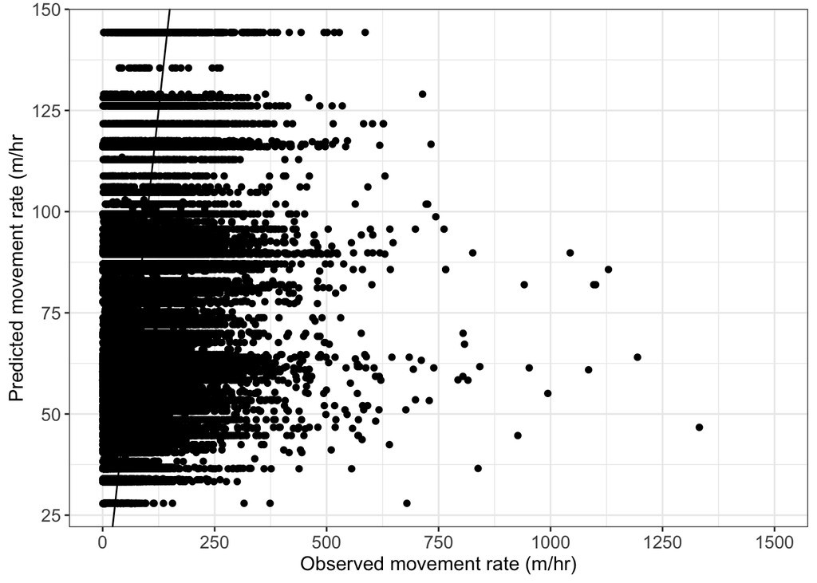

```r
## Predict test data and plot
test.dat <- dc[test.ids,]
test.dat$preds <- predict(tg, type = "response", newdata = test.dat)
test.dat$res <- test.dat$met.p.hr - test.dat$preds
ggplot(test.dat) +
  geom_point(aes(x = met.p.hr, y = preds)) +
  geom_abline(intercept = 0, slope = 1) +
  xlab("Observed movement rate (m/hr)") + ylab("Predicted movement rate (m/hr") +
  scale_y_continuous(breaks = seq(0, 150, by = 25)) + scale_x_continuous(breaks = seq(0, 1500, by = 250), limits = c(0, 1500), labels = seq(0, 1500, by = 250)) +
  theme_bw() +
  theme(axis.title = element_text(size = 12), axis.text = element_text(size = 11))
```

Our predictions for our hold-out test data aren’t outstanding; as described in the manuscript, it looks like our model predictions are tending to be underestimates.

Let’s close by plotting our model results with the weekly activity data (this is what’s included in the manuscript).

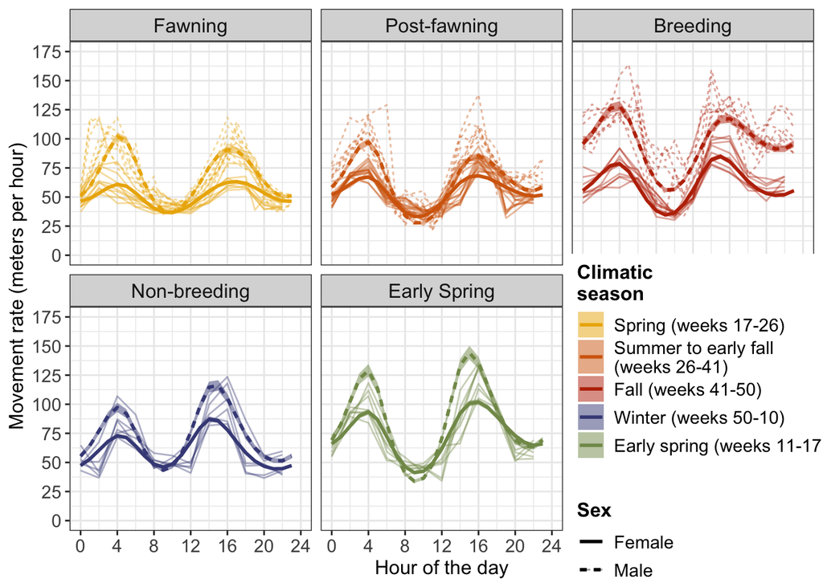

```r
## predict across our seasons, sexes, and hours of the day
season <- factor(c("fa", "pf", "br", "nb", "es"), levels = c("fa", "pf", "br", "nb", "es"))
sex <- c("Female", "Male")
hour.can <- seq(0, 23, by = 1)
pred.dat <- expand.grid(season, sex, hour.can)
colnames(pred.dat) <- c("season_5", "sex", "hour.can")

tp <- predict(tg, type = "link", newdata = pred.dat, se.fit = T)
pred.dat$preds <- tp$fit
pred.dat$se <- tp$se.fit
pred.dat$pred.resp <- exp(pred.dat$preds)
pred.dat$lowerCI <- exp(pred.dat$preds - (1.96*pred.dat$se))
pred.dat$upperCI <- exp(pred.dat$preds + (1.96*pred.dat$se))


## re-summarize weekly activity, splitting by sex
all.means <- ddply(dc, .(sex, season_5, week, hour.can), function(x) mean(x$met.p.hr))
all.tots <- ddply(dc, .(sex, season_5, week, hour.can), function(x) length(unique(x$id)))
colnames(all.tots) <- c("sex", "season_5", "week", "hour.can", "unique.n")
all.means <- left_join(all.means, all.tots, by = c("sex", "season_5", "week", "hour.can"))

all.means <- all.means[all.means$unique.n>=10,]

wk.obs <- ddply(all.means, .(sex, season_5, week), nrow)
wk.obs <- wk.obs[wk.obs$V1>=12,]

all.means.sub <- all.means[paste0(all.means$sex, all.means$season_5, all.means$week) %in% paste0(wk.obs$sex, wk.obs$season_5, wk.obs$week),]
all.means.sub$week.f <- factor(all.means.sub$week)
all.means.sub$season_5 <- factor(all.means.sub$season_5, levels = c("fa", "pf", "br", "nb", "es"))

all.means.sub$group <- paste(all.means.sub$week.f, all.means.sub$sex, sep = "_")

## plot model predictions and observed data together
pal <- met.brewer("VanGogh2", 9)[c(4, 2, 1, 9, 6)]
season.labs <- c("Fawning", "Post-fawning", "Breeding", "Non-breeding", "Early Spring")
names(season.labs) <- c("fa", "pf", "br", "nb", "es")

ggplot() +
    geom_line(data = all.means.sub, aes(x = hour.can, y = V1, group = group,  color = season_5, linetype = sex), alpha = 0.4) +
    geom_ribbon(data = pred.dat, aes(x = hour.can, ymin = lowerCI, ymax = upperCI, fill = season_5, group = sex), alpha = 0.5) +
    geom_line(data = pred.dat, aes(x = hour.can, y = pred.resp, colour = season_5, linetype = sex), linewidth = 1) +
    facet_wrap(~season_5, labeller = labeller(season_5 = season.labs)) +
    scale_colour_manual(values = pal, name = "Climatic\nseason", labels = c("Spring (weeks 17-26)", "Summer to early fall\n(weeks 26-41)", "Fall (weeks 41-50)",
                                                                  "Winter (weeks 50-10)", "Early spring (weeks 11-17)")) +
    scale_fill_manual(values = pal, name = "Climatic\nseason", labels = c("Spring (weeks 17-26)", "Summer to early fall\n(weeks 26-41)", "Fall (weeks 41-50)",
                                                                "Winter (weeks 50-10)", "Early spring (weeks 11-17)")) +
    scale_linetype_discrete(name = "Sex") +
    ylab("Movement rate (meters per hour)") + xlab("Hour of the day") +
    theme_bw() +
    scale_y_continuous(limits = c(0, 175), breaks = seq(0, 175, by = 25)) +
    scale_x_continuous(limits = c(0, 24), breaks = seq(0, 24, by = 4)) +
    theme(axis.title = element_text(size = 12), axis.text = element_text(size = 11), legend.text = element_text(size = 11),
          legend.title = element_text(size = 12, face = "bold"), strip.text = element_text(size = 12),
          legend.spacing.y = unit(0.5, "cm"),
          legend.position = "inside",
          legend.position.inside = c(0.85,0.22))
```

Even though our held-out predictions don’t look outstanding, in the broader scope of activity patterns, our model predictions actually look very reasonable. And that’s the end!